# Data Analysis of Avocado Price

## Introduction to the data

This dataset is taken from kaggle (https://www.kaggle.com/neuromusic/avocado-prices ) which sourced by website Hass Avocaco Board (https://hassavocadoboard.com).

This is how the data is described:

> The table below represents weekly 2018 retail scan data for National retail volume (units) and price. Retail scan data comes directly from retailers’ cash registers based on actual retail sales of Hass avocados. Starting in 2013, the table below reflects an expanded, multi-outlet retail data set. Multi-outlet reporting includes an aggregation of the following channels: grocery, mass, club, drug, dollar and military. The Average Price (of avocados) in the table reflects a per unit (per avocado) cost, even when multiple units (avocados) are sold in bags. The Product Lookup codes (PLU’s) in the table are only for Hass avocados. Other varieties of avocados (e.g. greenskins) are not included in this table.

Some relevant columns in the dataset:

`Date` - The date of the observation

`AveragePrice` - the average price of a single avocado

`type` - conventional or organic

`year` - the year

`Region` - the city or region of the observation

`Total Volume` - Total number of avocados sold

`4046` - Total number of avocados with PLU 4046 sold (Small Hass)

`4225` - Total number of avocados with PLU 4225 sold (Large Hass)

`4770` - Total number of avocados with PLU 4770 sold (Extra Large Hass)

## Data Loading

All the libraries and magic function use in this analysis are as listed below:

- pandas
- numpy
- matplotlib.pyplot
- seaborn
- statsmodels.api
- %matplotlib inline

The file provided is in csv form and the overview of the dataset looks like below when loaded. (I use Jupyter Notebook for this whole analysis process). There are a total of 18249 entries in this dataset containing 14 columns. No missing values are found in neither column.

|  | Unnamed: 0 | Date | AveragePrice | Total Volume | 4046 | 4225 | 4770 | Total Bags | Small Bags | Large Bags | XLarge Bags | type | year | region |
| --- | --- | --- | --- | --- | --- | --- | --- | --- | --- | --- | --- | --- | --- | --- |
| 0 | 0 | 2015-12-27 | 1.33 | 64236.62 | 1036.74 | 54454.85 | 48.16 | 8696.87 | 8603.62 | 93.25 | 0.0 | conventional | 2015 | Albany |
| 1 | 1 | 2015-12-20 | 1.35 | 54876.98 | 674.28 | 44638.81 | 58.33 | 9505.56 | 9408.07 | 97.49 | 0.0 | conventional | 2015 | Albany |
| 2 | 2 | 2015-12-13 | 0.93 | 118220.22 | 794.70 | 109149.67 | 130.50 | 8145.35 | 8042.21 | 103.14 | 0.0 | conventional | 2015 | Albany |
| 3 | 3 | 2015-12-06 | 1.08 | 78992.15 | 1132.00 | 71976.41 | 72.58 | 5811.16 | 5677.40 | 133.76 | 0.0 | conventional | 2015 | Albany |
| 4 | 4 | 2015-11-29 | 1.28 | 51039.60 | 941.48 | 43838.39 | 75.78 | 6183.95 | 5986.26 | 197.69 | 0.0 | conventional | 2015 | Albany |

## Data Cleaning

There are a few steps of data cleaning done in this dataset as listed below:

#### 1. Remove unwanted column

There are some other columns that exist in this dataset which are not described by the Hass Avocado Board and they are `Unnamed`,`Total Bags`,`Small Bags`,`Large Bags` and `XLarge Bags`. Since these columns are not my main concern in this dataset, I decided to removed them.

#### 2. Change datatype `Date` to datetime and `total volume`,`4046`,`4225` and `4770` to integer

Firstly, I changed the `Date` from **int64** to **datetime** datatype. Then, the columns `total volume`,`4046`,`4225` and `4770` are changed into **int** since they are the unit of avocado. If doesn't make sense if this value is in decimal.

So the final cleaned dataframe look like this:

|  | Date | AveragePrice | Total Volume | 4046 | 4225 | 4770 | type | year | region |
| --- | --- | --- | --- | --- | --- | --- | --- | --- | --- |
| 0 | 2015-12-27 | 1.33 | 64236 | 1036 | 54454 | 48 | conventional | 2015 | Albany |
| 1 | 2015-12-20 | 1.35 | 54876 | 674 | 44638 | 58 | conventional | 2015 | Albany |
| 2 | 2015-12-13 | 0.93 | 118220 | 794 | 109149 | 130 | conventional | 2015 | Albany |
| 3 | 2015-12-06 | 1.08 | 78992 | 1132 | 71976 | 72 | conventional | 2015 | Albany |
| 4 | 2015-11-29 | 1.28 | 51039 | 941 | 43838 | 75 | conventional | 2015 | Albany |

## EDA

The main objective in this part is to determine if there are any sort of patterns in our data.

For this Avocado Price dataset, what I intended to explore here are as below:

1. Explore the distribution and correlation of variables
2. Find any interesting trends?
3. Does volume has any impact on the avocado price?

### Distribution and Correlations of variables `AveragePrice`,`Total Volumn`, all three different PLU types using Seaborn pairplots

I used Pearson correlation here which measure the linear correlation between two variables X and Y. The purpose is to find the features that has high correlation value with AveragePrice (closer to +1 or -1).

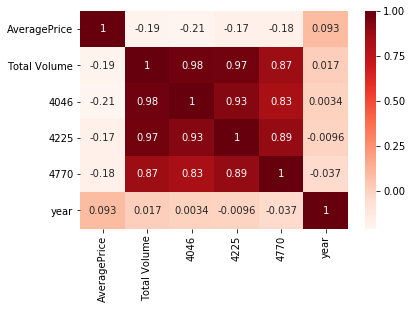

From the heatmap above, all of the features are weakly correlate with AveragePrice. Let's see how they are correlate within scatterplots because sometimes non linear correlation is more visible using scatterplots. We use pairplot for this purpose because we can see all the plots in one diagram.

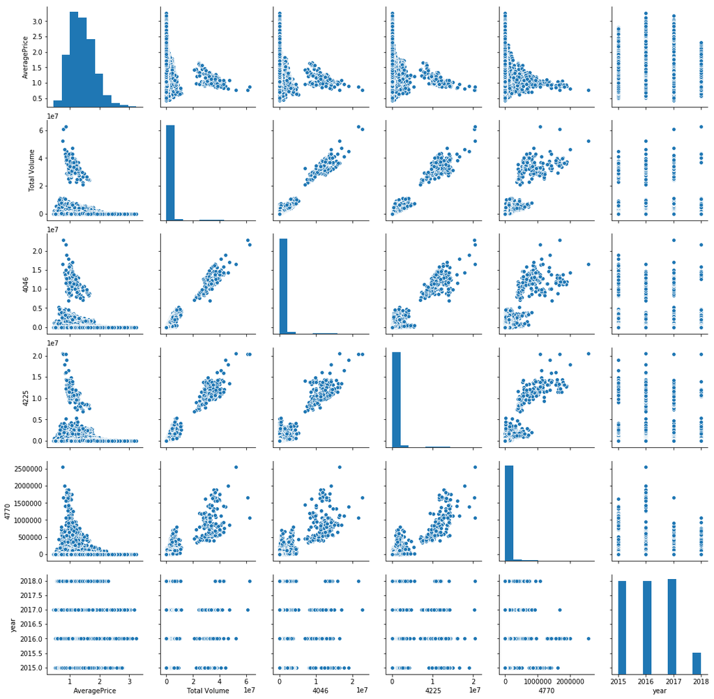

- What I noticed here is that most of the scatter plot seems to have 2 clusters. Is this represented by the type of avocado(organic and conventional)? lets plot again with type being the hue.
- Why does in the year histogram, the bar for 2018 seems far too less that other previous year? Is the data in not complete for that particular year?

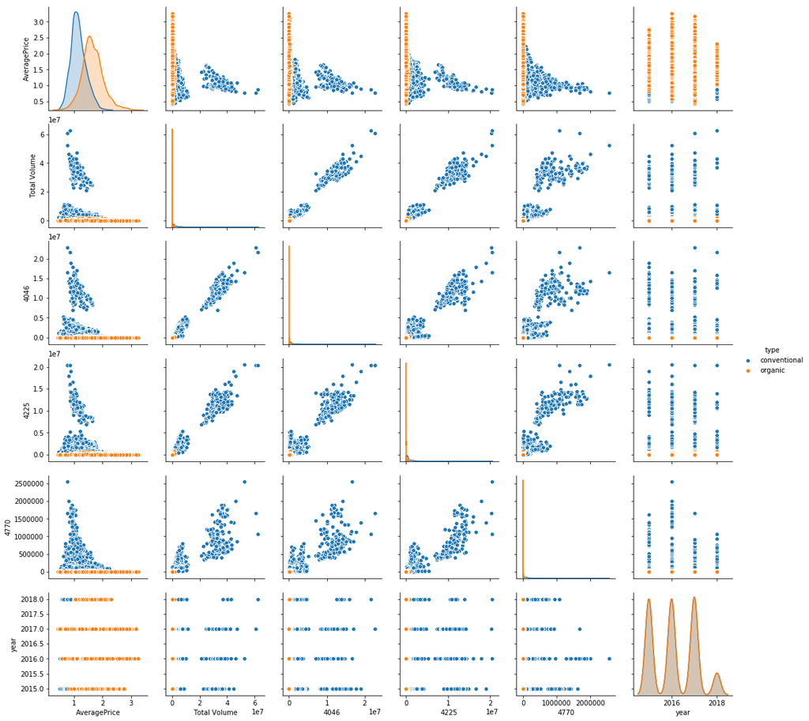

This show that type is not the cause of the clusters in the scatter plot. Assuming that there are standard of avocado volume sold in the market, I won't dig deeper into this but maybe I will do some research later regarding this.

So,my further analysis will be as below:

1. Since price is our dependent variable, we will try to uncover the price distribution closer
2. How price changes for different type of avocado?
3. How is the avocado's demand from year to year?
4. Do people eat more avocado during summer?

## Data Analysis and Visualisation

### Average Price distribution

My focus here is to see the price distribution for the Avocados alltogether and separately depending on their type (conventional and organic).

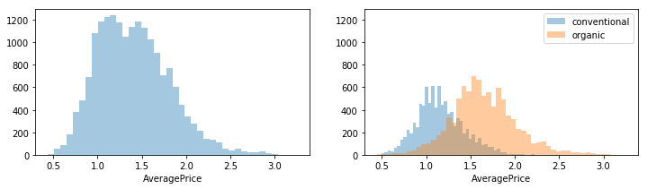

The average price for the avocado alltogether shows a bi-model distribution with right skewed. Meanwhile, the average price distribution for organic avocado is shifted to the right in the plot, which shows higher price on average than conventional avocado and more right skewed than the other type.

### Price changes for different type of avocado

I want to see how much are organic avocado usually cost compare to conventional avocado. To do this, I used linear model fit from statsmodel and the result are as below:

OLS Regression Results

| Dep. Variable: | AveragePrice | R-squared: | 0.379 |
| --- | --- | --- | --- |
| Model: | OLS | Adj. R-squared: | 0.379 |
| Method: | Least Squares | F-statistic: | 1.115e+04 |
| Date: | Tue, 06 Aug 2019 | Prob (F-statistic): | 0.00 |
| Time: | 10:11:03 | Log-Likelihood: | -4943.0 |
| No. Observations: | 18249 | AIC: | 9890. |
| Df Residuals: | 18247 | BIC: | 9906. |
| Df Model: | 1 |  |  |
| Covariance Type: | nonrobust |  |  |

|  | coef | std err | t | P>\|t\| | [0.025 | 0.975] |
| --- | --- | --- | --- | --- | --- | --- |
| intercept | 1.1580 | 0.003 | 348.692 | 0.000 | 1.152 | 1.165 |
| organic | 0.4960 | 0.005 | 105.588 | 0.000 | 0.487 | 0.505 |

| Omnibus: | 932.083 | Durbin-Watson: | 0.308 |
| --- | --- | --- | --- |
| Prob(Omnibus): | 0.000 | Jarque-Bera (JB): | 1410.720 |
| Skew: | 0.453 | Prob(JB): | 4.63e-307 |
| Kurtosis: | 4.017 | Cond. No. | 2.62 |

Warnings:  
[1] Standard Errors assume that the covariance matrix of the errors is correctly specified.

Based on the result above, if an avocado is conventional type, the price is predicted to be around 1.16 dollar. An organic avocado is predicted to be around 50 cent higher than a conventional avocado.

### How is the avocado demand from year to year?

|  | year | type | Total Volume | normed_total |
| --- | --- | --- | --- | --- |
| 0 | 2015 | conventional | 1075859426 | 0.978672 |
| 1 | 2015 | organic | 23445766 | 0.021328 |
| 2 | 2016 | conventional | 1265974189 | 0.977388 |
| 3 | 2016 | organic | 29289085 | 0.022612 |
| 4 | 2017 | conventional | 1321464239 | 0.969026 |
| 5 | 2017 | organic | 42238680 | 0.030974 |
| 6 | 2018 | conventional | 1334205761 | 0.964902 |
| 7 | 2018 | organic | 48531944 | 0.035098 |

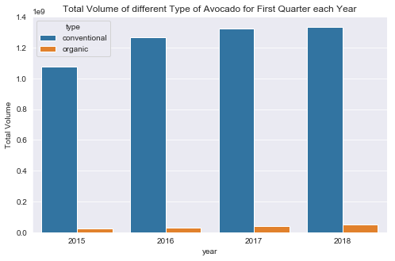

The total volume of the first quarter has positive increment yearly, and if compare 2018 to the last years in 2015, the the first quarter volume of Hass avocado has increase around 26%.

- can't really see the increment. Next try to normalize the frequency to sum to 1.

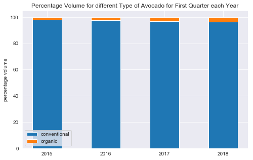

The percentage plot show that more people are buying organic avocado as the percentage organic avocado sold yearly increased slowly.

### Price changes with time series

We have seen how the price is distributed and even calculate the predictive price for both type of avocados before. So here we will focus on how the average price for the different type of avocado changes across the years.

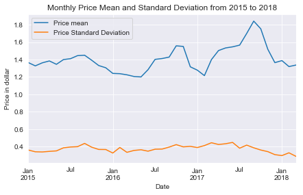

These are my findings from this plot:

- the increase of the avocado price seems to cause the higher fluctuation of avocado price.
- this is proven by looking at the graph where the spikes in average price (in this case take for example those higher than 1.40 dollar) correlate with standard deviation(spikes on orange line for value more than 0.4).
- What interesting is that the trend is most likely repetitive in the 3rd quarter yearly. why? is it correlate with the season like summer? because the price drop at year end and beginning of the next year.

Next I plotted the same graph but the type of avocado independently as below.

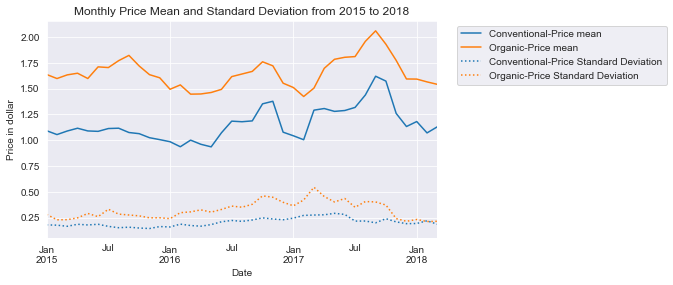

As expected, the average price for conventional avocado is always lower than the organic avocado. The price of avocado changes significantly in 2017 and fluctuate quite high (see the dotted lines). Based on CNN Business news, the two key drivers behind the summer price surge are a weak harvest for that particular year and insatiable demand for avocados. However, he average price for both type of avocados get more stable at the end of 2017 to the latest date in the dataset.

### Do people eat more avocado during summer?

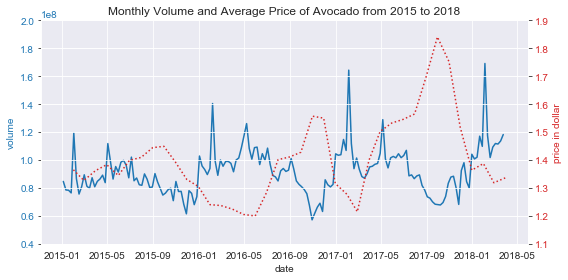

I expected that people eat more avocados in summer(June to August) but this data doesn't show any significant increase or drop during that period(refer blue line). What I find interesting are the spikes, which happened annually at end of January and continued with second spike in early May. Unfortunately, I'm not sure what are the reasons behind this. (I you do, do let me know.)

Moving to price and volumn, we know earlier during exploration part that they are not correlated with each other. However, I find it interesting that we can see for the past two years that when the demand is low for the yearly cycle, the price is more likely high for that particular period which we can see between Sept-Dec 2016 and 2017. This could be related to the harvest season of Hass avocado which extends from January through October and leads insufficient supply of avocado during off season to cater the demand.

## Outlook

### Conclusion

We know that organic product usually cost higher than conventional and this dataset has proved that. From our linear regression fit, a conventional avocado is predicted to cost 1.15 dollar and an organic avocado is predicted to cost 50 cent higher than that.

We also got to know how people love avocado in 2018 compare to three years back as the demand is getting higher. Overall the percentage of Hass avocado sold has increased for about 26% in first quarter 2018 compare to first quarter of 2015 and most of the sale is covered by conventional avocado yet organic avocado is getting more popularity from year to year.

So, if you are an avocado lover, now you know when is the best time to buy avocado before it get pricey!

Note: The details of the code for this analysis can be referred to this link: https://github.com/fatinshariff/Avocado_Price/blob/master/Avocado_price_Analysis.ipynb

**Further exploration ideas:**

1. Explore the region: Which region has high demand of avocados?
2. Have they always been the top avocado consumer?